# Day 1: Data Visualisation Fundamentals

# Imports and starter code

```r
library(dplyr)
library(gridExtra)
library(ggplot2)
library(readxl)
library(tidyr)

df <- read.csv("../../data/Malaria_Dataset_DataViz.csv")
```

# Exercise 1: Data wrangling

Time to have a first glance at the dataset!

1. Print the number of variables and observations in the dataset
2. Print the first 10 rows of the dataset
3. Write a function called `describe` that:
4. Selects the numeric columns that do not end with “id” in `df`
5. Creates a table for the remaining columns with the following summary statistics:
- min, Q1, median, mean, Q3, max
- the number of NaNs
- the data type (e.g., `numeric`)

**Solution: There are probably dozens of possibilities for this task! We show here three solutions**

```r
describe1 <- function(data) {
  # data: A data frame
  # return: Data frame with summary statistics for 'data'

  # Filter out non-numeric data and "id columns"
  # can also use summarise_if
  sub_data <- data %>%
    select_if(is.numeric) %>%
    select(-ends_with("id"))

  # Brute-force solution
  df_min <- sapply(sub_data, min)
  df_mean <- sapply(sub_data, mean)
  df_max <- sapply(sub_data, max)
  df_quarts <- sapply(sub_data, quantile, probs = c(0.25, 0.5, 0.75)) %>% t()
  types <- sapply(sub_data, class)
  num.na <- sapply(sub_data, function(x) sum(is.na(x)))
  nunique <- unlist(sub_data %>% summarise_all(n_distinct))

  my_summary <- data.frame(df_min, df_mean, df_quarts, df_max, types, num.na, nunique)

  my_summary
}

describe2 <- function(data) {
  # data: A data frame
  # return: Data frame with summary statistics for 'data'

  # Filter out non-numeric data and "id columns"
  # can also use summarise_if
  sub_data <- data %>%
    select_if(is.numeric) %>%
    select(-ends_with("id"))

  # Other solution using "reframe"
  get_summary <- function(x) {
    list(
      min = min(x, na.rm = TRUE),
      q1 = quantile(x, 0.25, na.rm = TRUE),
      q2 = quantile(x, 0.5, na.rm = TRUE),
      mean = mean(x, na.rm = TRUE),
      q3 = quantile(x, 0.75, na.rm = TRUE),
      max = max(x, na.rm = TRUE)
    )
  }

  my_summary <- as.data.frame(
    sub_data |>
      reframe(across(where(is.numeric), get_summary)) |>
      t()
  )

  rownames(my_summary) <- c("min", "Q1", "Q2", "Q3", "max")

  my_summary
}

describe3 <- function(data) {
  sub_data <- data %>%
    select_if(is.numeric) %>%
    select(-ends_with("id"))

  # Other solution using "summary"
  my_summary <- as.data.frame(
    do.call(
      rbind, lapply(
        sub_data, summary
      )
    )
  )
  my_summary$nunique <- c(sub_data %>% summarise_all(n_distinct))
  my_summary$type <- lapply(sub_data, class)
  my_summary$num.na <- lapply(sub_data, function(x) sum(is.na(x)))

  my_summary
}

describe3(df)
```

```
##                                                 Min.       1st Qu.
## latitude                               -2.910580e+01 -6.500000e+00
## longitude                              -1.749848e+01  2.844251e+00
## year_start                              1.995000e+03  2.008000e+03
## year_end                                1.995000e+03  2.008000e+03
## year                                    1.995000e+03  2.008000e+03
## lower_age                               0.000000e+00  3.000000e-01
## upper_age                               1.000000e+00  4.000000e+00
## Npositive                               0.000000e+00  0.000000e+00
## Nexamined                               1.000000e+00  1.200000e+01
## PfPr                                    6.600000e-05  6.600000e-05
## itnuse0                                 0.000000e+00  1.108407e-01
## itnuse1                                 0.000000e+00  7.532611e-02
## itnuse2                                 0.000000e+00  5.547262e-02
## itnuse3                                 0.000000e+00  4.057860e-02
## itnavg4                                 0.000000e+00  7.940135e-02
## act                                     1.064223e-02  3.144580e-01
## irs                                     0.000000e+00  0.000000e+00
## tasseled_cap_wetness                   -6.610296e-01 -2.874196e-01
## mosquito_temperature_suitability_index  0.000000e+00  4.366600e+04
## precipitation                           0.000000e+00  5.896000e+01
## enhanced_vegetation_index               1.427318e-03  2.129368e-01
## elevation                              -9.492000e+01  1.196800e+02
## nighttime_lights                        3.000000e+00  4.160000e+00
## accessibility_tocity                    7.500000e-01  7.152000e+01
##                                               Median          Mean
## latitude                                1.349250e+00  6.481154e-01
## longitude                               2.990042e+01  2.133483e+01
## year_start                              2.011000e+03  2.010924e+03
## year_end                                2.011000e+03  2.010934e+03
## year                                    2.011000e+03  2.010927e+03
## lower_age                               7.000000e-01  1.958753e+00
## upper_age                               5.000000e+00  2.196693e+01
## Npositive                               1.000000e+00  1.039274e+01
## Nexamined                               2.400000e+01  5.652764e+01
## PfPr                                    5.536191e-02  1.938571e-01
## itnuse0                                 3.168846e-01  3.311271e-01
## itnuse1                                 2.505204e-01  3.022578e-01
## itnuse2                                 2.073924e-01  2.672684e-01
## itnuse3                                 1.491138e-01  2.314580e-01
```

[output cut: 45 more lines]

```
## PfPr                                   numeric      0
## itnuse0                                numeric      0
## itnuse1                                numeric      0
## itnuse2                                numeric      0
## itnuse3                                numeric      0
## itnavg4                                numeric      0
## act                                    numeric      0
## irs                                    numeric      0
## tasseled_cap_wetness                   numeric      0
## mosquito_temperature_suitability_index integer      0
## precipitation                          numeric      0
## enhanced_vegetation_index              numeric      0
## elevation                              numeric      0
## nighttime_lights                       numeric      0
## accessibility_tocity                   numeric      0
```

# Exercise 2: univariate plots

Something should feel off regarding the column `mosquito_temperature_suitability_index`.

Let’s plot a histogram to check the distribution. Use both `hist` and `geom_histogram`.

Fix the data from `mosquito_temperature_suitability_index` in a new column called `mtsi` such that the summary looks like this:

```
  Min. 1st Qu.  Median    Mean 3rd Qu.    Max.
  0.00   43.67   59.51   58.59   77.14   94.04
```

**Solution: the temperature was accidentally multiplied by 1000 (normal range should be 0-100 according to the metadata), so simply divide by 1000 to obtain the mtsi column.**

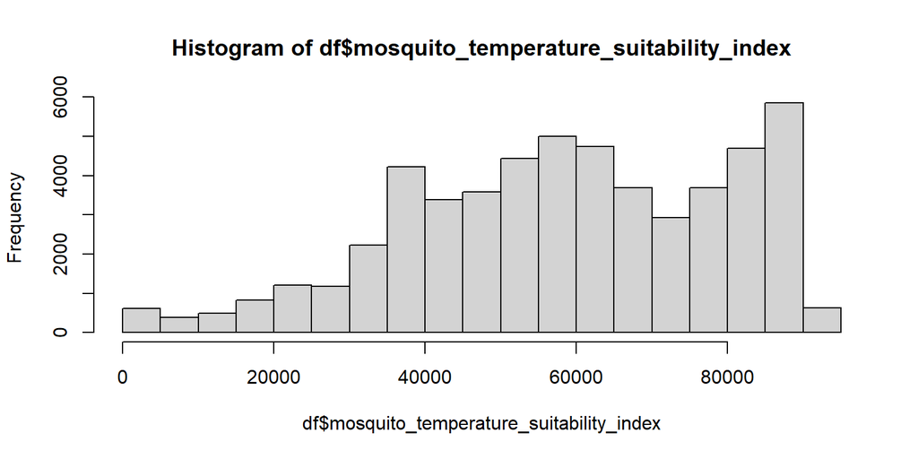

```r
# base R histogram
hist(df$mosquito_temperature_suitability_index)
```

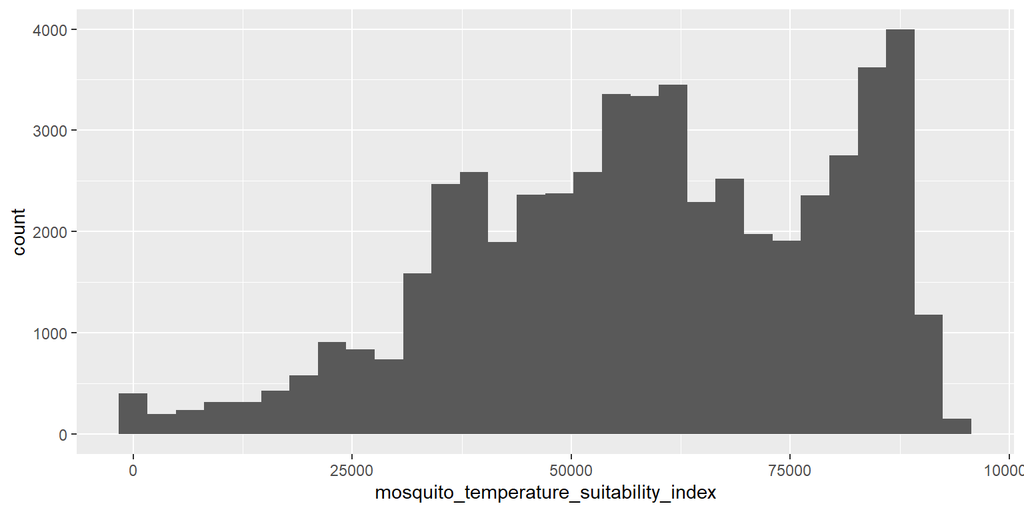

```r
# ggplot2 histogram
ggplot(df, aes(mosquito_temperature_suitability_index)) +
  geom_histogram()
```

````r
# Note: use "plot_grid" from the ```cowplot``` package
#       to plot base R and ggplot2 plots on the same window

df$mtsi <- df$mosquito_temperature_suitability_index / 1000
````

# Exercise 3: customising our univariate plot

Let’s customise our last plot (this time using the `mtsi` column)! Incorporate the following elements: - Add a vertical, red, dashed, line for the first three quartiles (Q1, median, Q3) - Better data-to-ink-ratio: opt for a white background - Add dashed grid lines - Increase the font size of the x and y ticks to 11

```r
mtsi_quantiles <- quantile(df$mtsi, probs = c(0.25, 0.5, 0.75))

fig <- ggplot(df, aes(mtsi)) +
  geom_histogram(fill = colourblind[1]) +
  labs(x = "Mosquito temperature stability") +
  # choose a minimal theme (no grey background)
  theme_minimal() +
  theme(
    # set grid lines
    panel.grid.major = element_line(color = "gray", linetype = "dashed"),
    # set font size of x axis
    axis.text.x = element_text(size = 11L),
    # set font size of y axis
    axis.text.y = element_text(size = 11L)
  ) +
  # add a vertical line
  geom_vline(
    # set xintercept as mtsi_quantiles
    xintercept = mtsi_quantiles,
    # dashed line
    linetype = "dashed",
    color = "red",
    linewidth = 1
  )
```

# Exercise 4: Bivariate plots

Plot a simple scatter plot showing the following:

- x-axis: precipitation
- y-axis: vegetation index

Assign the plot to the variable `fig1`

Augment `fig1` with:

- A linear regression model fit, coloured in dark red
- A title: “R^2 = xxx” where xxx is the value of R^2 from the linear regression model
- Better labels for the x- and y-axes.

Plot the two figures (fig1 and fig2) side by side. Are the results coherent?

**Solution:** Yes, we fully expect precipitation with vegetation 😄

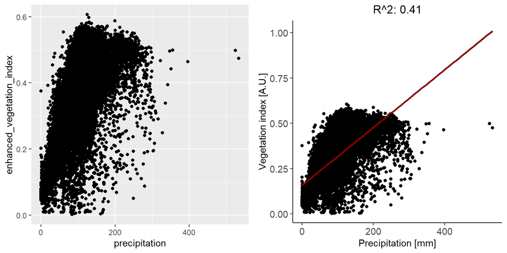

```r
fig1 <- ggplot(df, aes(y = enhanced_vegetation_index, x = precipitation)) +
  geom_point()

# Linear regression
mod <- lm(enhanced_vegetation_index ~ precipitation, df)

fig2 <- fig1 +
  # classic theme
  theme_classic() +
  # change x-axis, y-axis and title format
  theme(
    axis.text.x = element_text(size = 11L),
    axis.text.y = element_text(size = 11L),
    plot.title = element_text(hjust = 0.5) # centre the title
  ) +
  # Add the regression line
  geom_smooth(method = lm, color = "darkred") +
  # Change x-axis, y-axis and title labels
  labs(
    x = "Precipitation [mm]",
    y = "Vegetation index [A.U.]",
    title = paste("R^2:", format(summary(mod)$r.squared, digits = 2L))
  )

# Subplots with 2 columns
grid.arrange(fig1, fig2, ncol = 2L)
```

# Exercise 5: Focus on a single country

Find the country with the most observations in this dataset.

For this country, plot 4 subplots (in a 2 x 2 grid) showing the following:

1. The number of surveys done over the years, grouped by surved method
2. The average *Plasmodium falciparum* parasite rate (PfPr), plotted against the year (mean +/- standard deviation)
3. The distribution of PfPr depending on the area type (rural vs. urban)
4. Combine elevation, precipitation and city accessibility together

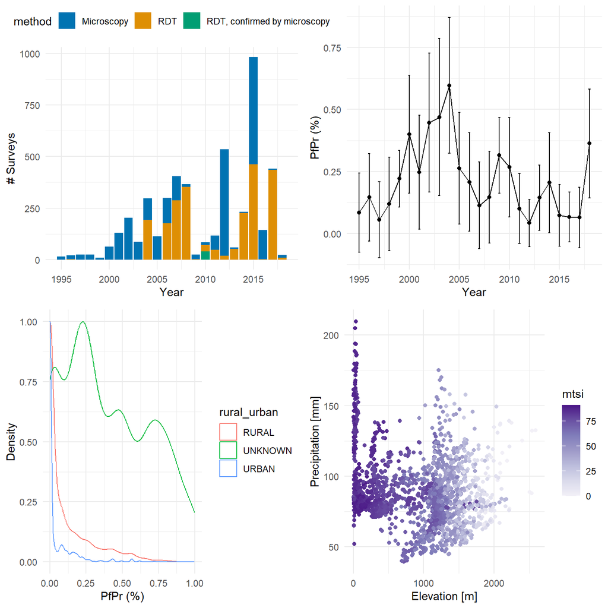

```r
# Using dplyr in full force here, but there are tons of other ways to do it
most_observed_country <- df %>%
  count(country, sort = TRUE) %>%
  head(1) %>%
  pull(country)

mocd <- df %>% filter(country == most_observed_country)

# Get mean and SD of PfPr grouped by year
mocd_pfpr_stats <- mocd %>%
  group_by(year) %>%
  summarise(PfPr_mean = mean(PfPr), PfPr_sd = sd(PfPr))

fig1 <- ggplot(mocd, aes(x = year, fill = method)) +
  geom_bar() +
  theme_minimal() +
  scale_fill_manual(values = colourblind) +
  labs(
    x = "Year",
    y = "# Surveys"
  ) +
  theme(legend.position = "top")

fig2 <- ggplot(data = mocd_pfpr_stats) +
  # Scatter plot
  geom_point(aes(x = year, y = PfPr_mean)) +
  # Line between each points
  geom_line(aes(x = year, y = PfPr_mean)) +
  # Error bar [y_mean - y_sd, y_mean + y_sd]
  geom_errorbar(
    aes(
      x = year,
      ymin = PfPr_mean - PfPr_sd,
      ymax = PfPr_mean + PfPr_sd
    ),
    width = 0.2
  ) +
  labs(
    x = "Year",
    y = "PfPr (%)"
  ) +
  theme_minimal()

fig3 <- ggplot(
  # Filter out empty values
  mocd %>% filter(rural_urban != ""),
  aes(x = PfPr, color = rural_urban)
) +
  # Use after_stat to scale the data
  geom_density(aes(y = after_stat(scaled))) +
  theme_minimal() +
  labs(
    y = "Density",
    x = "PfPr (%)",
  )

fig4 <- ggplot(mocd, aes(x = elevation, y = precipitation, colour = mtsi)) +
  geom_point() +
  theme_minimal() +
  scale_colour_distiller(palette = "Purples", direction = 1) +
  labs(
    y = "Precipitation [mm]",
    x = "Elevation [m]",
  )

grid.arrange(fig1, fig2, fig3, fig4, ncol = 2L)
```

# Exercise 6: Heatmaps

Compare the average usage of different types of insecticide-treated bed nets for Nigeria and its neighbours (Benin, Chad, Niger, Cameroon).

Plot the resulting table in a heatmap, with the value of each heatmap cell printed inside.

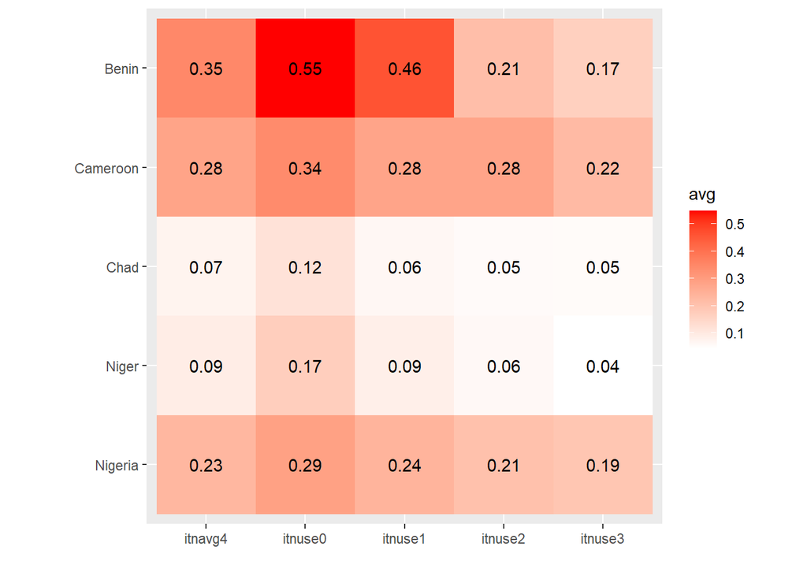

```r
ex6 <- df |>
  filter(country %in% c("Nigeria", "Benin", "Chad", "Niger", "Cameroon")) |>
  group_by(country) |>
  summarise(across(starts_with("itn"), mean)) |>
  gather(itn_variable, avg, -country)

ggplot(ex6, aes(y = country, x = itn_variable)) +
  # Make a heatmap in ggplot2
  geom_tile(aes(fill = avg)) +
  # Add text inside the heatmap
  geom_text(aes(label = round(avg, 2))) +
  # Make the heatmap squared
  coord_fixed() +
  # Change the gradient (white for low usage, red for high usage)
  scale_fill_gradient(low = "white", high = "red") +
  # Remove the x- and y-labels (for aesthetic purposes)
  xlab("") +
  ylab("") +
  # Change the country order such that it's alphabetically ordered
  ylim(rev(unique(ex6$country)))
```